# NY Shootings Analysis Post Great Recession - Covid

Thales

2023-05-10

**In this document, I will delve into the shootings that occurred in New York City from the post-Great Recession era (starting in 2010) up until the first two years of the Covid-19 Pandemic (2020-2022). Our goal is to analyze governmental datasets and identify potential factors that may have influenced these incidents. By doing so, we hope to gain a better understanding of the root causes of these shootings.**

### Fetch Reports

```r
library(tidyverse)
library(plyr)
nypd_report_url <- "https://data.cityofnewyork.us/api/views/833y-fsy8/rows.csv?accessType=DOWNLOAD"
ny_pop_report_url <- "https://data.ny.gov/api/views/krt9-ym2k/rows.csv?accessType=DOWNLOAD&sorting=true"
raw_nypd_report = read_csv(nypd_report_url)
raw_ny_pop_report <- read_csv(ny_pop_report_url)
```

### Apply necessary tranformations for further Analysis

```r
report <- raw_nypd_report %>%
          select(-X_COORD_CD, -Y_COORD_CD, -Latitude, -Longitude, -INCIDENT_KEY, - Lon_Lat, -PRECINCT, -LOC_CLASSFCTN_DESC, -LOC_OF_OCCUR_DESC, -LOCATION_DESC, -JURISDICTION_CODE)


report$OCCUR_DATE <- as.Date(report$OCCUR_DATE, format = "%m/%d/%Y")

report <- report %>%
            mutate(Year = lubridate::year(OCCUR_DATE)) %>%
            filter(Year >= 2010)

nyc_counties_list <- c("Bronx County", "Kings County", "New York County", "Queens County", "Richmond County")

ny_pop_report <- raw_ny_pop_report %>%
                    filter(Geography %in% nyc_counties_list & Year >= 2010) %>%
                    mutate(
                      BORO = case_when(
                        Geography == "Bronx County" ~ "BRONX",
                        Geography == "Kings County" ~ "BROOKLYN",
                        Geography == "New York County" ~ "MANHATTAN",
                        Geography == "Queens County" ~ "QUEENS",
                        Geography == "Richmond County" ~ "STATEN ISLAND",
                        )
                    ) %>%
                    select(-"FIPS Code", -"Program Type", -"Geography") %>%
                    arrange(Year)
```

### Summarize Data for periods of interest

```r
incidents_10_19 <- report %>%
    filter(Year >= 2010 & Year < 2020) %>%
    group_by(Year) %>%
    dplyr::summarize(total_cases = n())

incidents_10_22 <- report %>%
    filter(Year >= 2010 & Year < 2023) %>%
    group_by(Year) %>%
    dplyr::summarize(total_cases = n())


incidents_per_boro_10_19 <- report %>%
    filter(lubridate::year(OCCUR_DATE) < 2020) %>%
    group_by(BORO, Year) %>%
    dplyr::summarize(`Total Cases` = n())
incidents_per_boro_10_22 <- report %>%
    filter(lubridate::year(OCCUR_DATE) >= 2010) %>%
    group_by(BORO, Year) %>%
    dplyr::summarize(`Total Cases` = n())
pop_report_10_22 <- merge(
                      incidents_per_boro_10_22,
                      ny_pop_report,
                      by=c("BORO","Year"),
                      all.x=TRUE
                      )

pop_report_10_19 <- merge(
                      incidents_per_boro_10_19,
                      ny_pop_report,
                      by=c("BORO","Year"),
                      all.x=TRUE
                      )
```

### Merge summarised data with dataset containg population and adding calculated columns

```r
deaths_per_boro_10_19 <- report %>%
                  filter(Year < 2020 & STATISTICAL_MURDER_FLAG == TRUE) %>%
                  group_by(BORO, Year) %>%
                  dplyr::summarize(Deaths = n()) %>%
                  arrange(BORO, Year)
deaths_per_boro_10_22 <- report %>%
                  filter(Year >= 2010 & STATISTICAL_MURDER_FLAG == TRUE) %>%
                  group_by(BORO, Year) %>%
                  dplyr::summarize(Deaths = n()) %>%
                  arrange(BORO, Year)
full_trend_report_10_19 <- merge(
                            pop_report_10_19,
                            deaths_per_boro_10_19,
                            by=c("BORO","Year"),
                            all.x=TRUE
                            )


full_trend_report_10_22 <- merge(
                            pop_report_10_22,
                            deaths_per_boro_10_22,
                            by=c("BORO","Year"),
                            all.x=TRUE
                            )

pop_report_10_19 <- full_trend_report_10_19 %>%
    mutate("Incidents per 100k residents " = (`Total Cases`/Population)*10.0**4) %>%
    mutate("Deaths per 100k residents " = (Deaths/Population)*10.0**4)


pop_report_10_19 <- pop_report_10_19 %>%
  mutate(`Incidents per 100k residents ` = round(`Incidents per 100k residents `, digits = 2)) %>%
  mutate(`Deaths per 100k residents ` = round(`Deaths per 100k residents `, digits = 2))


pop_report_10_22 <- full_trend_report_10_22 %>%
    mutate("Incidents per 100k residents " = (`Total Cases`/Population)*10.0**4) %>%
    mutate("Deaths per 100k residents " = (Deaths/Population)*10.0**4)


pop_report_10_22 <- pop_report_10_22 %>%
  mutate(`Incidents per 100k residents ` = round(`Incidents per 100k residents `, digits = 2)) %>%
  mutate(`Deaths per 100k residents ` = round(`Deaths per 100k residents `, digits = 2))
```

### Shootings trend 2010 - 2019

**We can observe a downward trend in the number of shootings in the period after The Great Recession Until 2019 (before the Covid Pandemic Crisis)**

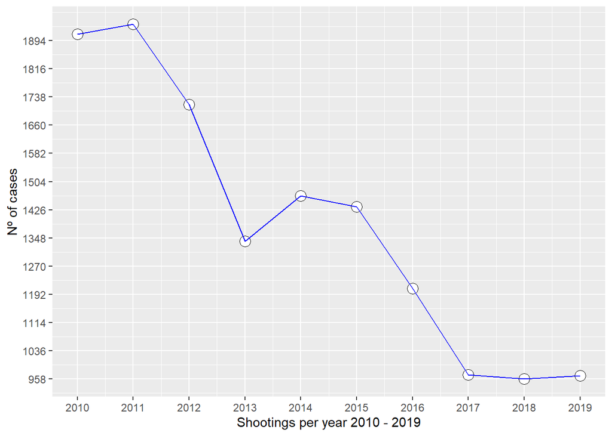

```r
ggplot(data = incidents_10_19, aes(x = Year, y = total_cases)) +
  geom_point( size=4, shape=21, fill="white") + geom_line(color = "blue") +
  xlab("Year") +
  ylab("Nº of cases") +
  ggtitle("Shootings per year 2010 - 2019") %>%
  scale_x_continuous(
    breaks=seq(
      min(incidents_10_19$Year),
      max(incidents_10_19$Year),
      by=1
      )
    ) +
  scale_y_continuous(
    breaks=seq(
      min(incidents_10_19$total_cases)
      ,max(incidents_10_19$total_cases)
      ,
      by=78
      )
    )
```

[figure not shown]

```r
ggplot(data=pop_report_10_19,aes(x=Year,y=`Incidents per 100k residents `,group=BORO,colour=BORO)) +
    geom_line() +
    geom_point( size=4, shape=21, fill="white") +
    scale_x_continuous(
      breaks=seq(
        min(pop_report_10_19$Year),
        max(pop_report_10_19$Year),
        by=1
        )
      ) +
    scale_y_continuous(
      breaks=seq(
        0,
        max(pop_report_10_19$`Incidents per 100k residents `),
        by=0.25
        )
      )
```

[figure not shown]

```r
ggplot(data=pop_report_10_19, aes(x=Year,y=`Deaths per 100k residents `,group=BORO,colour=BORO)) +
    geom_line() +
    geom_point( size=4, shape=21, fill="white") +
    scale_x_continuous(
      breaks=seq(
        min(pop_report_10_19$Year),
        max(pop_report_10_19$Year),
        by=1
        )
      ) +
    scale_y_continuous(
      breaks=seq(
        0,
        max(pop_report_10_19$`Deaths per 100k residents `),
        by = 0.1
        )
      )
```

## Upward trend in shootings starting in 2020

**During the Pandemic, we can observe a spike in the number of cases**

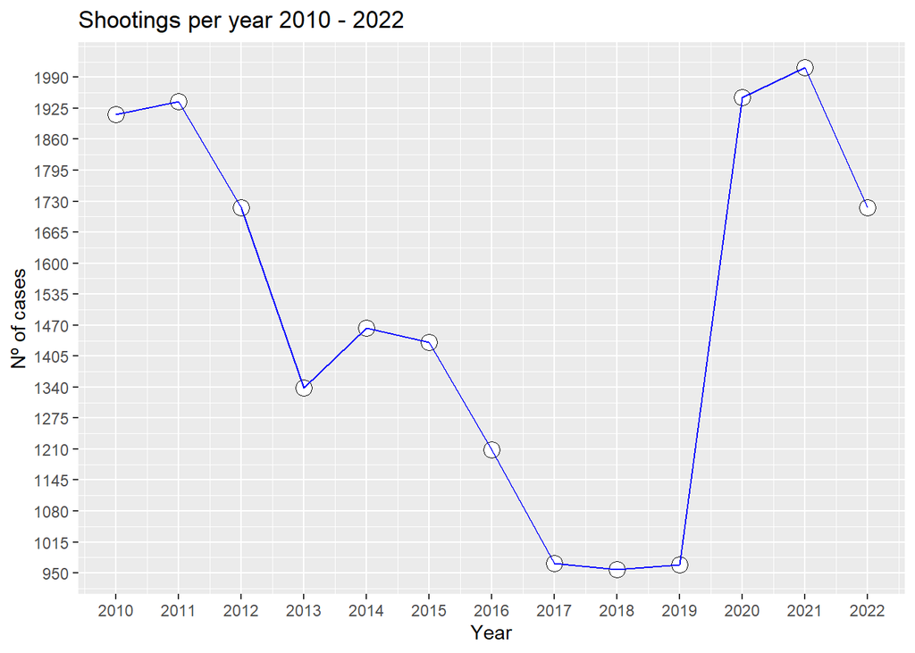

```r
ggplot(data = incidents_10_22, aes(x = Year, y = total_cases)) +
  geom_point(size=4, shape=21, fill="white") + geom_line(color = "blue") +
  xlab("Year") +
  ylab("Nº of cases") +
  ggtitle("Shootings per year 2010 - 2022") +
  scale_x_continuous(
    breaks=seq(
      min(incidents_10_22$Year),
      max(incidents_10_22$Year),
      by=1
      )
    ) +
  scale_y_continuous(
    breaks=seq(
      950,
      max(incidents_10_22$total_cases),
      by = 65
      )
    )
```

**Also observed in every Borough in NYC**

[figure not shown]

```r
ggplot(data=pop_report_10_22,aes(x=Year,y=`Incidents per 100k residents `,group=BORO,colour=BORO)) +
    geom_line() +
    geom_point( size=4, shape=21, fill="white") +
    ggtitle("Incidents per 100k residents  2010 - 2022") +
    scale_x_continuous(
      breaks=seq(
        min(pop_report_10_22$Year),
        max(pop_report_10_22$Year),
        by=1
        )
      ) +
    scale_y_continuous(
      breaks=seq(
        0,
        max(pop_report_10_22$`Incidents per 100k residents `),
        by=0.25
        )
      )
```

[figure not shown]

```r
ggplot(data=pop_report_10_22, aes(x=Year, y=`Deaths per 100k residents `, group = BORO, colour = BORO)) +
    geom_line() +
    geom_point( size=4, shape=21, fill="white") +
    ggtitle("Deaths per 100k residents  2010 - 2022") +
    scale_x_continuous(breaks = seq(min(pop_report_10_22$Year), max(pop_report_10_22$Year), by = 1)) +
    scale_y_continuous(breaks = seq(0, max(pop_report_10_22$`Deaths per 100k residents `), by = 0.1))
```

**The unemployment rate could be a factor that contributes to the increase in gun violence. We’ll import a New York State Dataset and analyze if there is a relationship for further discussion**

### Importing NY unemployment dataset

```r
unemployment_url  <- "https://fred.stlouisfed.org/graph/fredgraph.csv?bgcolor=%23e1e9f0&chart_type=line&drp=0&fo=open%20sans&graph_bgcolor=%23ffffff&height=450&mode=fred&recession_bars=on&txtcolor=%23444444&ts=12&tts=12&width=1319&nt=0&thu=0&trc=0&show_legend=yes&show_axis_titles=yes&show_tooltip=yes&id=NYUR&scale=left&cosd=1976-01-01&coed=2023-03-01&line_color=%234572a7&link_values=false&line_style=solid&mark_type=none&mw=3&lw=2&ost=-99999&oet=99999&mma=0&fml=a&fq=Monthly&fam=avg&fgst=lin&fgsnd=2020-02-01&line_index=1&transformation=lin&vintage_date=2023-05-10&revision_date=2023-05-10&nd=1976-01-01"

unemployment_report = read_csv(unemployment_url)
unempleyment_yearly_summary <- unemployment_report %>%
  mutate(Year = lubridate::year(DATE)) %>%
  filter(Year > 2005 & Year < 2023) %>%
  group_by(Year) %>%
  summarise_at(vars(NYUR), list(`Unemployment Rate` = mean)) %>%
  mutate(`Unemployment Rate` = round(`Unemployment Rate`, digits = 2))
```

### Analyzing unemployment rate over the same period

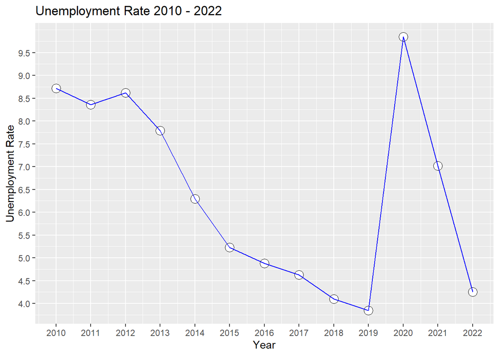

```r
ggplot(data = unempleyment_yearly_summary %>% filter(Year >= 2010),aes(x=Year,y =`Unemployment Rate`)) +
  geom_point( size=4, shape=21, fill="white") + geom_line(color = "blue") +
  xlab("Year") +
  ylab("Unemployment Rate") +
  ggtitle("Unemployment Rate 2010 - 2022") +
  scale_x_continuous(
    breaks=seq(
      min(unempleyment_yearly_summary$Year),
      max(unempleyment_yearly_summary$Year),
      by=1
      )
    ) +
  scale_y_continuous(
    breaks=seq(
      0,
      max(unempleyment_yearly_summary$`Unemployment Rate`),
      by=0.5
      )
    )
```

### Merging Unenmployment and Shooting Incidents Datasets

```r
shootings_unemployment_set <- merge(
                                incidents_10_22,
                                unempleyment_yearly_summary %>%
                                  filter(Year >= 2010),
                                by=c("Year"),
                                all.x=TRUE
                                )
```

### Pearson correlation Analysis

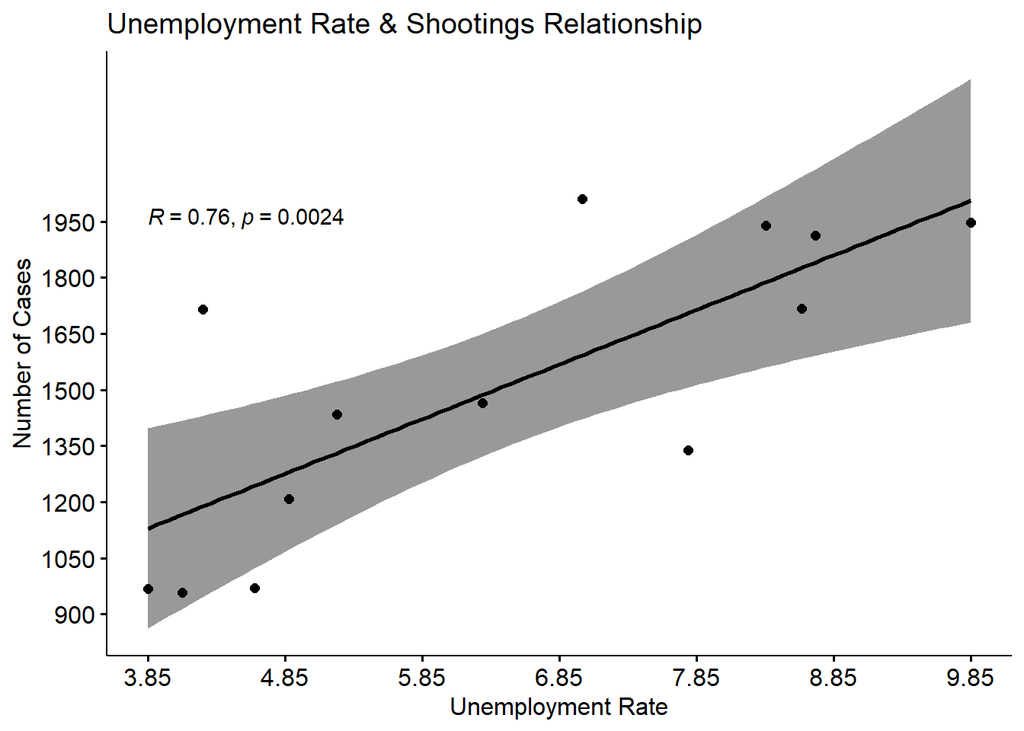

```r
library("ggpubr")
ggscatter(shootings_unemployment_set, x = "Unemployment Rate", y = "total_cases",
          add = "reg.line", conf.int = TRUE,
          cor.coef = TRUE, cor.method = "pearson",
          xlab = "Unemployment Rate", ylab = "Number of Cases") +
          ggtitle("Unemployment Rate & Shootings Relationship") +
          scale_x_continuous(
            breaks=seq(
              min(shootings_unemployment_set$`Unemployment Rate`),
              max(shootings_unemployment_set$`Unemployment Rate`),
              by=1
              )
            ) +
          scale_y_continuous(
            breaks=seq(
              0,
              max(shootings_unemployment_set$total_cases),
              by=150
              )
            )
```

With a correlation of 0.76 and a P value of 0.0024, the data suggests that the unemployment could be related to the Number of Shootings in NYC.

### Linear regression Analysis

```r
relation <- lm(shootings_unemployment_set$`Unemployment Rate`~shootings_unemployment_set$total_cases)
relation
```

```
##
## Call:
## lm(formula = shootings_unemployment_set$`Unemployment Rate` ~
##     shootings_unemployment_set$total_cases)
##
## Coefficients:
##                            (Intercept)  shootings_unemployment_set$total_cases
##                               0.431318                                0.003982
```

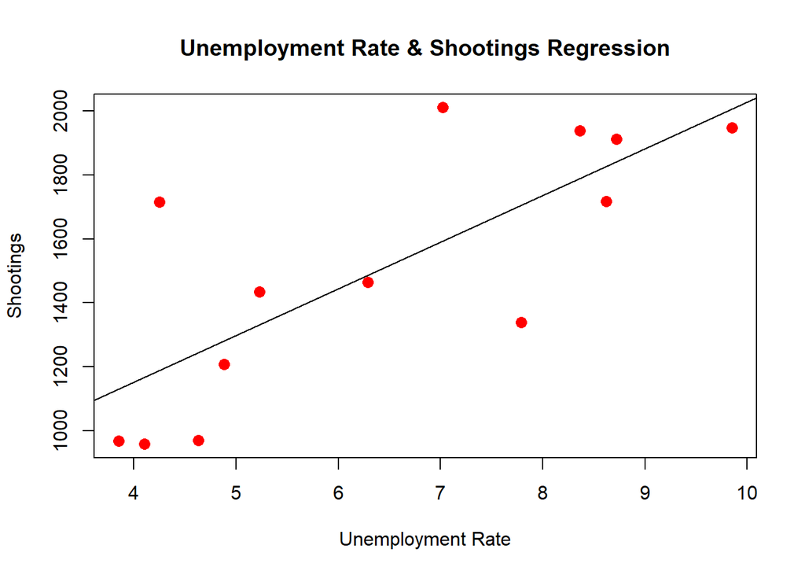

```r
# Plot the chart.
plot(
  shootings_unemployment_set$`Unemployment Rate`,
  shootings_unemployment_set$total_cases,
  col = "red",
  main = "Unemployment Rate & Shootings Regression",
  abline(
    lm(
      shootings_unemployment_set$total_cases~shootings_unemployment_set$`Unemployment Rate`
      ))
  ,cex = 1.3,
  pch = 16,
  xlab = "Unemployment Rate",
  ylab = "Shootings"
  )
```

**The linear regression plot also suggests that variations in the Unemployment Rate could be a factor that contributes to variations in shooting incidents in NYC, as observed in the spike during 2020-2022.**

### Possible Bias Sources

- Unemployment rates were based on average value for New York State over 2010-2022, therefore including rates for all Boroughs/Counties in the state
- Boroughs and Counties were assumed to be interchangeable (eg: “Kings County” ~ “Brooklyn”) for population mapping
- A more in depth analysis would be necessary, including other factors like income distribution, poverty levels, and correlation with other criminal activities in order to better understand the observed trend